# Probability Distributions

## Announcements

- Reminder to join the ids702-fa25 Slack channel
- HW1 posted, due Sunday 11:59 PM

## Warm-up Questions (Wooclap on Canvas > Assignments)

## Random Variables

**Random variables** are variables that can take different values, and the value they take depends on a probabilistic process.

Examples:

| Y=Resting heart rate | Y=congestive heart failure status (1=Yes, 0=No) |
| --- | --- |
| 80 | 0 |
| 82 | 1 |
| 78 | 0 |
| 90 | 1 |
| 65 | 0 |

## Probability Distributions

A **probability distribution** is a function that maps a possible outcome of a random variable to its probability of occurrence.

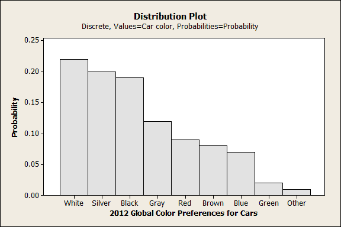

Image source: https://blog.minitab.com/en/adventures-in-statistics-2/understanding-and-using-discrete-distributions

## Key Components of Probability Distributions

- Support: values that the distribution can take
- Parameters: values that characterize the distribution
- PDF/PMF: $f(x)$ , function whose output is a probability of a particular value or range of values
- CDF: $F(x)$ , function whose output is a cumulative probability up to a particular value
- Expected value/mean: $\mathbf{E}(X)$
- Variance: $\mathbf{E}[(X-\mu)^2]$

## Example

| $X$ | 1 | 2 | 3 | 4 |
| --- | --- | --- | --- | --- |
| $P(X=x)$ | 0.2 | 0.4 | 0.3 | 0.1 |

- Is this a valid probability distribution?
- Is this a discrete or continuous distribution?
- What is the support?
- What is $P(X=3)$?
- What is $F(3)$?
- What is $\mathbf{E}(X)$?
- What is $Var(X)$?

- Is this a valid probability distribution?
- Is this a discrete or continuous distribution?
- What is the support?
- What is $P(X=3)$?
- What is $F(3)$?

- What is $\mathbf{E}(X)$?
- What is $Var(X)$?
  - $Var(X)=\mathbf{E}[(X-\mu)^2]=\mathbf{E}[X^2]-\mathbf{E}[X]^2$ (do this on your own)

## Common Probability Distributions

1. Normal
2. t
3. Bernoulli
4. Binomial
5. Uniform
6. Multinomial
7. Poisson
8. Negative Binomial